# Budweiser Data Analysis

# Merging brewery and beer data

```r
all_data=merge(breweries, new, by.x = "Brew_ID", by.y = "Brewery_id")
#Verifying that there are no NA's
sapply(all_data, function(x) sum(is.na(x))) #No NA's
```

```
## Brew_ID  Name.x    City   State  Name.y Beer_ID     ABV     IBU   Style  Ounces
##       0       0       0       0       0       0       0       0       0       0
## ABV_ind
##       0
```

- First 6 observations of all the data

```r
kable(head(all_data,6),"simple")
```

| Brew_ID | Name.x | City | State | Name.y | Beer_ID | ABV | IBU | Style | Ounces | ABV_ind |
| --- | --- | --- | --- | --- | --- | --- | --- | --- | --- | --- |
| 1 | NorthGate Brewing | Minneapolis | MN | Stronghold | 2688 | 0.060 | 25 | American Porter | 16 | 5 |
| 1 | NorthGate Brewing | Minneapolis | MN | Parapet ESB | 2687 | 0.056 | 47 | Extra Special / Strong Bitter (ESB) | 16 | 4 |
| 1 | NorthGate Brewing | Minneapolis | MN | Pumpion | 2689 | 0.060 | 38 | Pumpkin Ale | 16 | 5 |
| 1 | NorthGate Brewing | Minneapolis | MN | Get Together | 2692 | 0.045 | 50 | American IPA | 16 | 2 |
| 1 | NorthGate Brewing | Minneapolis | MN | Maggie’s Leap | 2691 | 0.049 | 26 | Milk / Sweet Stout | 16 | 2 |
| 1 | NorthGate Brewing | Minneapolis | MN | Wall’s End | 2690 | 0.048 | 19 | English Brown Ale | 16 | 2 |

- Last 6 observations of all the data

```r
kable(tail(all_data,6),"simple")
```

|  | Brew_ID | Name.x | City | State | Name.y | Beer_ID | ABV | IBU | Style | Ounces | ABV_ind |
| --- | --- | --- | --- | --- | --- | --- | --- | --- | --- | --- | --- |
| 2342 | 556 | Ukiah Brewing Company | Ukiah | CA | Pilsner Ukiah | 98 | 0.055 | 31.50 | German Pilsener | 12 | 4 |
| 2343 | 557 | Butternuts Beer and Ale | Garrattsville | NY | Snapperhead IPA | 51 | 0.068 | 79.75 | American IPA | 12 | 7 |
| 2344 | 557 | Butternuts Beer and Ale | Garrattsville | NY | Moo Thunder Stout | 50 | 0.049 | 16.75 | Milk / Sweet Stout | 12 | 2 |
| 2345 | 557 | Butternuts Beer and Ale | Garrattsville | NY | Porkslap Pale Ale | 49 | 0.043 | 16.75 | American Pale Ale (APA) | 12 | 2 |
| 2346 | 557 | Butternuts Beer and Ale | Garrattsville | NY | Heinnieweisse Weissebier | 52 | 0.049 | 16.75 | Hefeweizen | 12 | 2 |
| 2347 | 558 | Sleeping Lady Brewing Company | Anchorage | AK | Urban Wilderness Pale Ale | 30 | 0.049 | 16.75 | English Pale Ale | 12 | 2 |

# Calculating bitterness and alcohol mean per State

```r
#IBU mean per State
ibu_state=all_data %>% group_by(State) %>% summarize(IBU_mean=mean(IBU))
abv_state=all_data %>% group_by(State) %>% summarize(ABV_mean=mean(ABV))
#Combine both ABV and IBU count per state
IBU_ABV=merge(abv_state,ibu_state, by="State", all.y=TRUE)
#intersect((head((IBU_ABV %>% arrange(desc(ABV_mean))  %>% select(State)),10)),(head((IBU_ABV %>% arrange(desc(IBU_mean)) %>% select(State)),10))) #Common states in the top 10 for both IBU and ABV
```

```r
#Bitterness average per State
IBU_ABV$State= factor(IBU_ABV$State, level =IBU_ABV$State[order(IBU_ABV$IBU_mean)])
plot1=IBU_ABV %>% ggplot(aes(y=State, x=IBU_mean, color=State)) + geom_col(width=.5) +
  ggtitle("Bitternes average per State") + xlab("Bitternes average") +
  ylab("State")+
  theme(axis.text = element_text(size = 9))

#ABV average per State
IBU_ABV$State= factor(IBU_ABV$State, level =IBU_ABV$State[order(IBU_ABV$ABV_mean)])
plot2=IBU_ABV %>% ggplot(aes(y=State, x=ABV_mean, color=State)) + geom_col(width=.5) +
  ggtitle("Alcohol average per State") + xlab("Alcohol by volume average") +
  ylab("State") +
  theme(axis.text = element_text(size = 9))
```

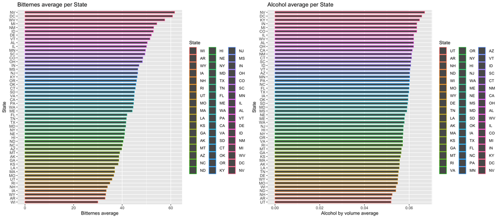

```r
grid.arrange(plot1, plot2, ncol=2)
```

- The highest mean bitterness unit average state is Nevada while the lowest is Wisconsin
- State with the highest alcohol average per state is Nevada and lowest is UTAH

**Top 3 states with highest Bitterness**

```r
kable(head(ibu_state %>% arrange(desc(IBU_mean)),3),"simple")
```

| State | IBU_mean |
| --- | --- |
| NV | 61.57500 |
| DC | 60.71875 |
| WV | 57.50000 |

**States with Lowest Bitternes unit**

```r
kable(head(ibu_state %>% arrange(IBU_mean),3) ,"simple")
```

| State | IBU_mean |
| --- | --- |
| WI | 29.97059 |
| AR | 32.95000 |
| WY | 33.21667 |

**Top states with highest Alcohol volume**

```r
#ABV mean per State
kable(head(abv_state %>% arrange(desc(ABV_mean)),3) ,"simple")
```

| State | ABV_mean |
| --- | --- |
| NV | 0.066900 |
| DC | 0.065625 |
| KY | 0.064600 |

**States with Lowest Alcohol unit**

```r
kable(head(abv_state %>% arrange((ABV_mean)),3) ,"simple")
```

| State | ABV_mean |
| --- | --- |
| UT | 0.0518846 |
| AR | 0.0520000 |
| NH | 0.0523750 |